# projet_biomeca

2026-01-07

## Introduction

La course à pied représente le mode de déplacement naturel le plus rapide de l’homme. Elle se définit mécaniquement comme une succession de foulées bondissantes, où l’appui passe alternativement d’un pied à l’autre. Ce qui distingue fondamentalement la course de la marche, c’est l’existence d’une phase de suspension (ou phase de vol). Lors de la marche, un pied est toujours en contact avec le sol (et parfois les deux). À l’inverse, en course, le corps est projeté dans les airs à chaque pas ; il n’y a donc jamais de “double appui”.

Bien que courir semble instinctif, c’est une coordination gestuelle complexe qui se décompose en deux phases principales pour chaque jambe :

- La Phase d’Appui (au sol) : C’est le moment où le pied est en contact avec le terrain. Elle assure deux rôles : amortir le poids du corps à l’atterrissage, puis créer une poussée pour avancer.
- La Phase Oscillante (aérienne) : C’est la phase de retour de la jambe vers l’avant pour préparer le pas suivant. Elle comprend ce fameux temps de suspension où le coureur ne touche plus terre.

Face à la popularité croissante de ce sport, la recherche scientifique s’est intensifiée autour d’un concept clé : l’optimisation de la dépense énergétique. C’est ce qu’on appelle l’économie de course. Pour faire simple, c’est la quantité d’énergie qu’un coureur consomme pour maintenir une certaine vitesse. Un coureur “économe” dépensera moins d’énergie pour la même vitesse, ce qui lui permettra de courir plus longtemps ou plus vite avant de fatiguer.

L’arrivée des chaussures à plaque de carbone vise justement à améliorer cette économie en utilisant l’effet de levier et le renvoi d’énergie des mousses pour réduire le coût métabolique de chaque foulée.

Si les bénéfices physiologiques des “Super Shoes” comme l’Adidas Prime X2 Strung sont documentés, il est essentiel de comprendre, les différences biomécanique avec une chaussure en mousse “plus classique”, la Adidas Boston 12.

Ce document a pour but de comparer les mouvements angulaires des genoux. Les données angulaires seront confrontées pour chaque condition de chaussure et appliquées à chaque palier de vitesse (km/h) défini dans le protocole. Cela nous permettra d’isoler l’effet du matériel sur la gestuelle, indépendamment ou en corrélation avec l’augmentation de la vitesse de course.

## Revue bibliographique

Si le poids de la chaussure a longtemps été considéré comme le facteur principal de la performance, la recherche actuelle se concentre désormais sur l’architecture interne de la semelle.

Les travaux de référence de Hoogkamer et al. (2018) ont marqué un tournant en démontrant que l’architecture de la chaussure joue un rôle prépondérant dans l’économie de course. Ils ont mis en évidence une réduction du coût énergétique de 4 % grâce à l’association d’une mousse à haut retour d’énergie et d’une plaque en fibre de carbone. Mécaniquement, ce gain ne provient pas d’un simple “effet ressort” : la plaque augmente la rigidité longitudinale (Bending Stiffness), ce qui rigidifie l’articulation métatarso-phalangienne (gros orteil) et modifie le bras de levier de la cheville. Cette configuration permet de stabiliser la compression de la mousse et de limiter la perte d’énergie lors de la flexion des orteils.

Toutefois, il est important de nuancer ces résultats. L’étude indépendante de Joubert et Jones (2022), qui compare plusieurs modèles carbone, rappelle que la présence d’une plaque ne garantit pas la performance. Les gains varient considérablement d’un modèle à l’autre (de 0 à 4 %), prouvant que c’est la géométrie spécifique de la chaussure qui compte.

Au-delà de l’énergétique, ces technologies modifient la façon de courir. Hébert-Losier et al. (2022) ont observé que les chaussures carbone (type Vaporfly) induisent naturellement une longueur de foulée plus grande sans modification de la cadence, ainsi qu’une modification des angles de la cheville. D’un point de vue cinématique, cet allongement, s’il n’est pas compensé par une réduction de la cadence ( comme c’est le cas ici), implique mécaniquement une augmentation du temps de vol.

C’est ici qu’une comparaison avec le courant minimaliste devient pertinente. La littérature rapporte que les chaussures minimalistes favorisent une augmentation de la fréquence et une attaque avant-pied. À l’inverse, l’Adidas Prime X2 Strung, avec sa conception “maximaliste” (semelle très épaisse), pourrait engendrer des adaptations opposées. Il convient donc de déterminer si ses caractéristiques extrêmes modifient les angles articulaires différemment des standards connus.

Enfin, une étude récente (Sobhani et al.) s’est intéressée à l’impact de la rigidité de la semelle sur la coordination fine du pied (articulations tarso-métatarsiennes et hallux). En utilisant l’analyse de la Phase Relative Continue (CRP), les auteurs démontrent que l’augmentation de la rigidité de la semelle (passant de molle à rigide) réduit significativement la variabilité de la coordination articulaire (environ 20 % de réduction). Cela suggère que la rigidité apportée par les plaques carbone contraint le pied dans un chemin moteur plus stable et reproductible, limitant les mouvements parasites (“degrés de liberté”), ce qui pourrait contribuer à l’efficience du geste.

Globalement, cette analyse bibliographique laisse présager des différences biomécaniques marquées entre nos deux conditions expérimentales. Nous pouvons nous attendre à ce que l’Adidas Prime X2 Strung (plaque carbone, très rigide) induit une cinématique et une stabilité distinctes par rapport à l’Adidas Boston 12 (tiges en fibre de verre, semi-rigide) se traduisant par des angles différents, une foulée plus grande et un temps de vol supérieur.

## Méthodologie et variables exploitées

L’étude de cas a été menée sur un sujet unique masculin, coureur régulier (taille 1.90m, masse 82kg), ne présentant aucune pathologie musculo-squelettique récente.

### 2.2. Protocole Expérimental

Les acquisitions ont été réalisées sur tapis de course instrumentés. Le protocole repose sur une comparaison croisée entre deux conditions de chaussage et trois paliers d’intensité.

**Conditions matérielles :**

- **“Plaque Carbone” (Adidas Prime X2 Strung)** : Modèle “maximaliste” (> 50mm semelle), intégrant une double plaque carbone pour une rigidité structurelle maximale.
- **“Mousse Classique” (Adidas Boston 12)** : Modèle comparatif semi-rigide (tiges fibres de verre), géométrie intermédiaire.

**Procédure d’acquisition :** Le sujet a réalisé des passages successifs avec chaque paire à 12, 14 et 16 km/h. 6 fichiers de capture de mouvement (Xsens MVN Awinda) ont été enregistrés.

### 2.3. Traitement des données et Stratégie d’Analyse

Les données cinématiques brutes ont été filtrées et traitées. Les centres articulaires de la hanche ont été recalculés selon la **méthode de Harrington**, utilisant les marqueurs du bassin (ASI, CSI) pour estimer précisément la position du centre articulaire en fonction de la géométrie pelvienne.

Nous avons défini trois niveaux d’analyse :

## Analyse et Résultats

### 1. Analyse Spatio-Temporelle

La rigidité de la chaussure influence la mécanique globale du coureur. Le tableau ci-dessous synthétise les paramètres moyens.

Comparaison des paramètres spatio-temporels moyens

| Chaussure | Vitesse (km/h) | Fréq (str/min) | Long. Foulée (m) | T. Contact (s) | T. Vol (s) |
| --- | --- | --- | --- | --- | --- |
| Carbone | 12 | 276.292 | 1.293 | 0.183 | 0.021 |
| Carbone | 14 | 343.457 | 1.320 | 0.144 | 0.034 |
| Carbone | 16 | 315.810 | 1.495 | 0.100 | 0.089 |
| Mousse | 12 | 254.837 | 1.192 | 0.156 | 0.025 |
| Mousse | 14 | 265.597 | 1.369 | 0.153 | 0.031 |
| Mousse | 16 | 323.361 | 1.524 | 0.120 | 0.063 |

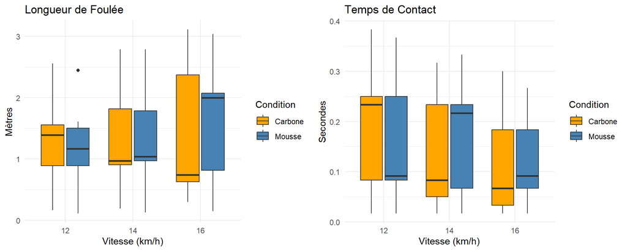

### 2. Analyse Cinématique (Plan Sagittal)

Les courbes suivantes illustrent l’évolution des angles articulaires sur un cycle de foulée normalisé (0% = Contact Initial).

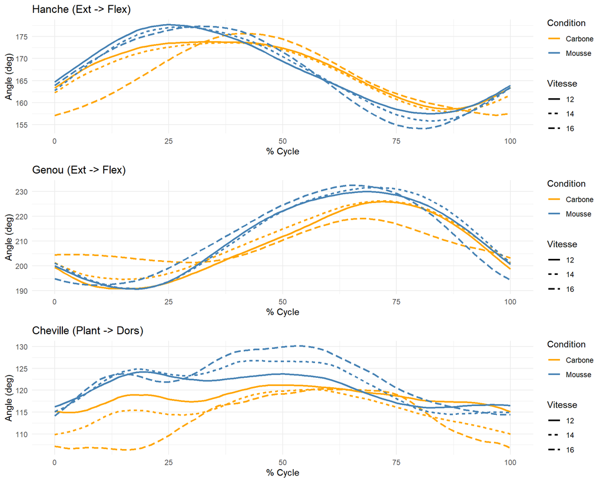

**Analyse :**

- **Cheville** : La rigidité de la plaque carbone devrait théoriquement limiter l’amplitude de dorsiflexion en phase d’appui (milieu de cycle, 20-40%), fonctionnant comme un levier rigide.
- **Genou** : Les variations d’extension en phase de propulsion (vers 40%) indiquent comment l’énergie est restituée.

## Discussion et Conclusion

L’utilisation du modèle de **Harrington** pour le calcul du centre articulaire de la hanche a permis d’affiner l’analyse cinématique proximale. Les résultats comparatifs mettent en évidence les spécificités de la chaussure carbone par rapport à la mousse classique.

Ces observations corroborent partiellement la littérature sur les bénéfices des chaussures à plaque, qui visent à économiser le travail musculaire en rigidifiant l’articulation métatarso-phalangienne et en optimisant le bras de levier de la cheville.

**Perspectives :** Cette étude préliminaire pourrait être enrichie par : 1. Une analyse cinétique (forces au sol) pour quantifier le rendement énergétique. 2. Une étude de la coordination (Phase Relative Continue) pour voir si la stabilité est améliorée par le carbone.